# Оценка уровня террористической угрозы для туристов в Турции

Артём Конопелько | myonin@ya.ru

15 сентября 2016 г.

## Введение

**Цель исследования:** Оценить уровень террористической угрозы для туристов, отдыхающих в Турции.

**Актуальность:** Нормализация русско-турецких отношений вызвало увеличение числа российских туристов, отдыхающих в Турции, в целях безопасности наших сограждан необходимо реально оценить риски, которым они могут подвергаться во время отдыха в Турции.

**Задачи:**

1. Оценить уровень террористической активности в Турции;
2. Классифицировать жертвы террористических атак и вычислить наиболее частые;
3. Выявить наиболее активные террористические организации, выяснить их мотивацию;
4. Установить зоны наибольшей террористической активности и определить точки их пересечения с основными туристическими направлениями;
5. По результатам исследования подготовить рекомендации для российских туристов.

**Гипотеза:** Опасность террористической угрозы для иностранных туристов незначительная.

Для исследования использованы данные Университета Мэриленда [(The Global Terrorism Database (GTD)](https://www.start.umd.edu/gtd/contact/) и Министерства культуры и туризма Турции [Number of Arrivals and Nights Spent, Average lenght of Stay and Occupancy Rate in Establishments by Proviences](http://yigm.kulturturizm.gov.tr/TR,9858/belediye-belgeli-tesisler.html).

## Оценка уровня террористической активности в Турции

По данным Университета Мэриленда (The Global Terrorism Database), в 2015 г. в РФ совершен 21 теракт, в Турции — 416. C 2000 по 2011 гг. россиянам на Средиземноморском побережье было гораздо безопаснее, чем на Родине, сейчас ситуация несколько иная. В РФ в плане террористической активности гораздо спокойнее — где-то в 20 раз, чем в Турции.

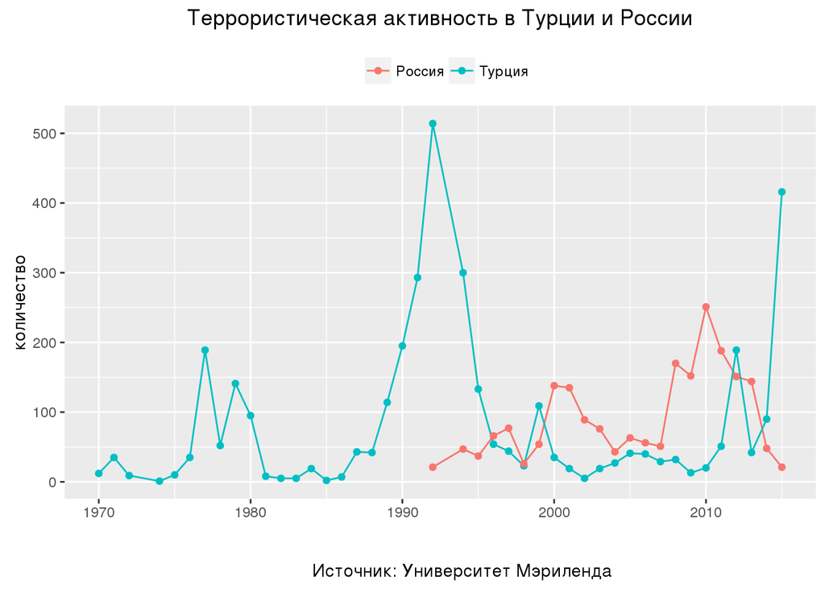

В новейшей турецкой истории было три периода, когда террористические организации действовали особо активно. Первый длился с 1975 по 1980 гг., за это время совершено 522 теракта, в среднем 87 за год. Второй — с 1987 по 1997 гг.: 1732 теракта, 157 за год. Третий — с 2011 г. по настоящее время: всего 788, по 158 за год. То есть последний всплеск насилия пока не самый продолжительный, но имеет все шансы стать самым кровавым.

## Выявление основных жертв террористических атак

Гражданские лица становятся жертвами атак только в 14% случаев. Большинство нападений происходит на армейские подразделения (28%) и полицию (25%).

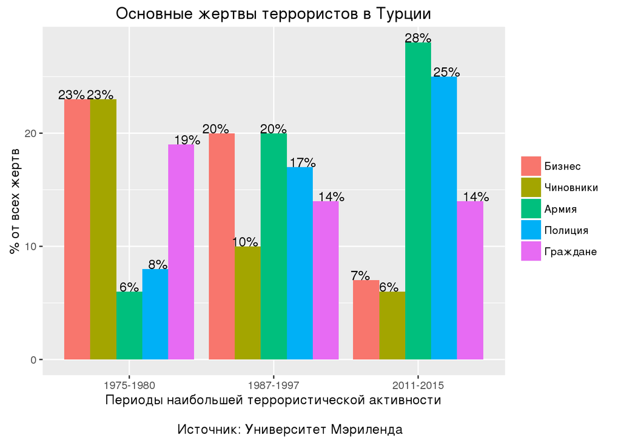

## Выявление наиболее активных террористических организаций

На долю ИГИЛ приходится менее 2% всех терактов в Турции. С начала 90-х первое место с большим отрывом занимает Рабочая партия Курдистана — именно её активисты осуществили 74% всех атак с 2011 по 2015 годы.

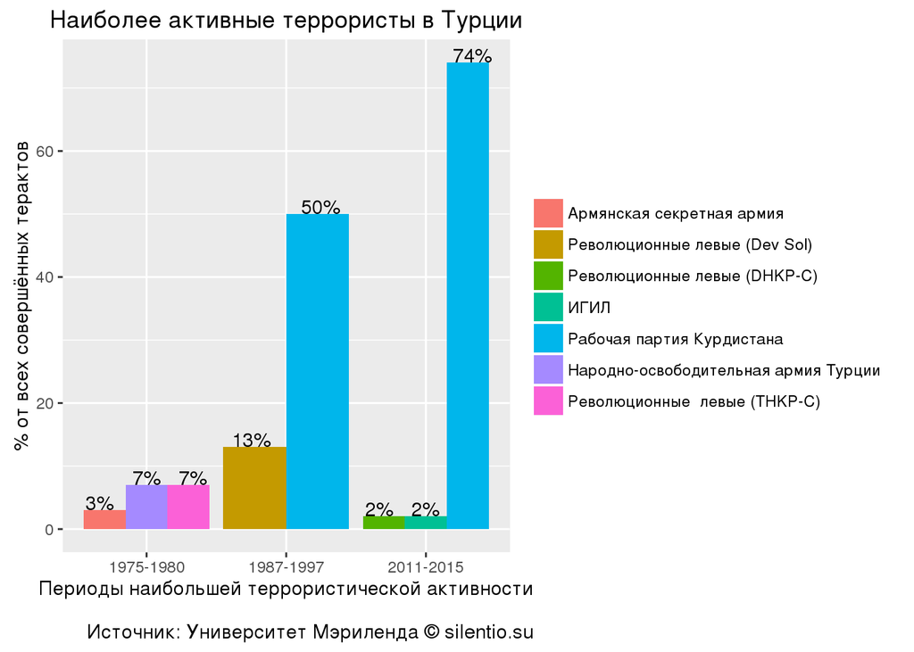

То есть вопреки сложившимся ожиданиям вовсе не исламистские радикалы, жаждущие крови неверных по умолчанию, являются основным источником террористической угрозы, а курды, идеология которые не подразумевает уничтожения мирных граждан других государств.

## Cравнение основных туристических направлений с зонами наибольшей террористической активности

По данным Министерства культуры и туризма Турции, туристы предпочитают отдыхать на Средиземноморском побережье: в 2015 году Анталия приняла 45% всех отдыхающих, Мугла — 10%, Измир — 4%. Большинство же терактов совершаются в юго-восточных, приграничных с Сирией, Ираком, Ираном и Арменией областях страны.

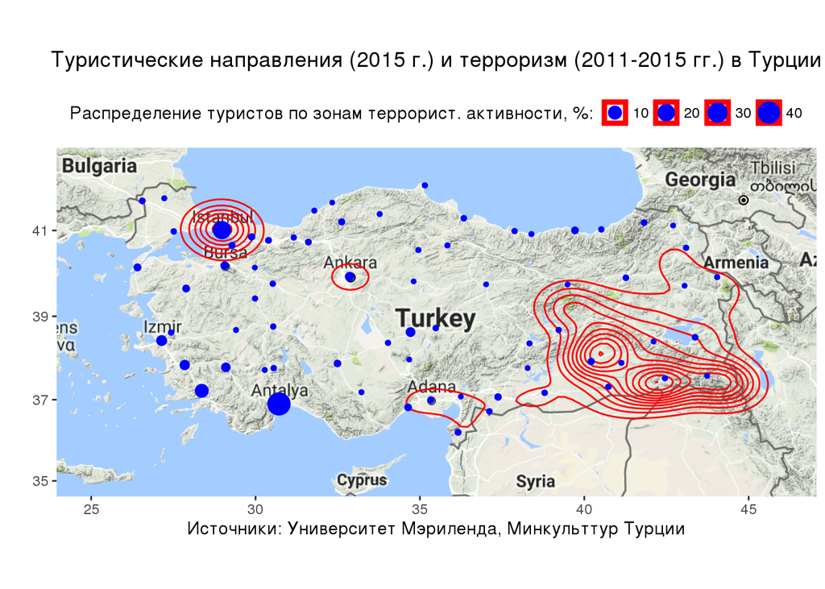

Однако точки пересечения всё же существуют. Наиболее опасный город — Стамбул, там останавливается 23% приезжих и совершается 9% терактов. На втором месте — Анкара, 2% туристов и 2% терактов. На третьем — Адана, всего лишь 0,25% туристов и менее 1% терактов.

## Выводы

**Основной вывод:** Вероятность стать жертвой террористов в Турции для иностранных туристов небольшая.

## Рекомендации

Можно порекомендовать гражданам не находиться рядом с воинскими частями, не бежать на звуки пулемётных очередей в надежде сделать эксклюзивное селфи, побольше загорать и купаться и поменьше посещать исторические достопримечательности Стамбула и Анкары, тогда вероятность попасть в новостные выпуски резко уменьшается.